# KunalChhajer_Assignment_SequentialNLP_Part2

## Import Libraries

```python
# Import packages
import warnings; warnings.filterwarnings('ignore')
import pandas as pd, numpy as np, tensorflow as tf
import matplotlib.pyplot as plt, seaborn as sns
import matplotlib.style as style

import random, re
%matplotlib inline

# Models
from tensorflow.keras.layers import Dense, LSTM, Embedding, Dropout, Flatten, Bidirectional, GlobalMaxPool1D, SpatialDropout1D
from tensorflow.keras.callbacks import EarlyStopping, ModelCheckpoint, ReduceLROnPlateau, TensorBoard
from tensorflow.keras.preprocessing.sequence import pad_sequences
from tensorflow.keras.preprocessing.text import Tokenizer
from tensorflow.keras.models import Model, Sequential
from tensorflow.keras.initializers import Constant

from sklearn.metrics import classification_report, confusion_matrix
from sklearn.model_selection import train_test_split

# Set random state
random_state = 42
np.random.seed(random_state)
tf.random.set_seed(random_state)
```

```python
# Code to Measure time taken by program to execute.
import time

# store starting time
begin = time.time()

# program body starts

for i in range(5000):
    print("GeeksForGeeks")
# program body ends

## time.sleep(1)
# store end time
end = time.time()

# total time taken
print(f"Total runtime of the program is {end - begin}")
```

[output not shown]

[output cut: 4946 more lines]

[output not shown]

## Loading Dataset

```python
data = pd.read_json('./Sarcasm_Headlines_Dataset.json', lines = True)
print('Data Shape:')
print(data.shape)
display(data.head())
```

```
Data Shape:
(28619, 3)
```

|  | is_sarcastic | headline | article_link |
| --- | --- | --- | --- |
| 0 | 1 | thirtysomething scientists unveil doomsday clo... | https://www.theonion.com/thirtysomething-scien... |
| 1 | 0 | dem rep. totally nails why congress is falling... | https://www.huffingtonpost.com/entry/donna-edw... |
| 2 | 0 | eat your veggies: 9 deliciously different recipes | https://www.huffingtonpost.com/entry/eat-your-... |
| 3 | 1 | inclement weather prevents liar from getting t... | https://local.theonion.com/inclement-weather-p... |
| 4 | 1 | mother comes pretty close to using word 'strea... | https://www.theonion.com/mother-comes-pretty-c... |

## Value Counts for is_sarcastic label

[figure not shown]

```python
data['is_sarcastic'].value_counts().plot(kind = 'pie', autopct = '%.0f%%', labels = ['Sarcastic', 'Non-sarcastic'], figsize = (10, 6))
plt.show()
```

## Analysis of `is_sarcastic` label by news website

```python
hf = data[data['article_link'].str.contains('huffingtonpost.com')].shape[0]
op = data[data['article_link'].str.contains('theonion.com')].shape[0]

is_sarcastic_hf = data.loc[(data['article_link'].str.contains('huffingtonpost.com')) & (data['is_sarcastic'] == 1)].shape[0]
not_sarcastic_hf = data.loc[(data['article_link'].str.contains('huffingtonpost.com')) & (data['is_sarcastic'] == 0)].shape[0]

is_sarcastic_op = data.loc[(data['article_link'].str.contains('theonion.com')) & (data['is_sarcastic'] == 1)].shape[0]
not_sarcastic_op = data.loc[(data['article_link'].str.contains('theonion.com')) & (data['is_sarcastic'] == 0)].shape[0]

display(pd.DataFrame([[is_sarcastic_hf, is_sarcastic_op], [not_sarcastic_hf, not_sarcastic_op]],
                     columns = ['huffingtonpost', 'theonion'], index = ['Sarcastic', 'Non-sarcastic']))
```

|  | huffingtonpost | theonion |
| --- | --- | --- |
| Sarcastic | 0 | 13634 |
| Non-sarcastic | 14985 | 1 |

## Checking 5 random headlines and labels from the data

```python
rands = random.sample(range(1, data.shape[0]), 5)
headlines, labels = list(data.loc[rands, 'headline']), list(data.loc[rands, 'is_sarcastic'])

for head, label in zip(headlines, labels):
  print(f'Headline: {head}\nlabel: {label}\n')
```

```
Headline: ted cruz voices support for states' right to legalize marijuana
label: 0

Headline: mad men: om is where the heart is
label: 0

Headline: content writer awkwardly shows parents around website where he works
label: 1

Headline: scientists finally pronounce human genome
label: 1

Headline: charles durning hocks up four-pound chunk of phlegm
label: 1
```

## Checking 5 random headlines and labels from the data where the length of headline is > 100

```
Headline: mother of slaying victim glad it was onion reporter who knocked on her door half an hour after funeral
label: 1

Headline: 'game of thrones' fans shocked after some little goblin or something killed off in last night's episode
label: 1

Headline: woman walking alone at night picks up pace after spotting truck full of alabama lawmakers slowly following her
label: 1

Headline: experts warn climate change will increase incidences of stepping into puddle and getting whole goddamn foot soaking wet
label: 1

Headline: nutritious lunch brought from home broadcasts middle-aged coworker's recent health scare loud and clear
label: 1

============================================================
Distributon of label where the length of headline is > 100
============================================================
```

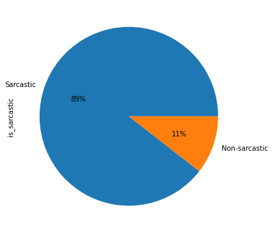

```python
indexes = list(data.loc[data['headline'].str.len() > 100, 'headline'].index)
rands = random.sample(indexes, 5)
headlines, labels = list(data.loc[rands, 'headline']), list(data.loc[rands, 'is_sarcastic'])

for head, label in zip(headlines, labels):
  print(f'Headline: {head}\nlabel: {label}\n')

print('============================================================')
print('Distributon of label where the length of headline is > 100')
print('============================================================')
data.loc[indexes, 'is_sarcastic'].value_counts().plot(kind = 'pie', autopct = '%.0f%%', labels = ['Sarcastic', 'Non-sarcastic'], figsize = (10, 6));
```

## Dropping article_link column from the data

```python
data.drop('article_link', axis = 1, inplace = True)
```

## Important Functions

```python
# Import packages
import nltk; nltk.download('wordnet'); nltk.download('stopwords')
from nltk.stem import WordNetLemmatizer
from nltk.corpus import wordnet as wn
from nltk.corpus import stopwords
from wordcloud import WordCloud
import matplotlib.pyplot as plt
import string

nltk.download('averaged_perceptron_tagger')

contractions = {
  "ain't": "am not / are not",
  "aren't": "are not / am not",
  "can't": "cannot",
  "can't've": "cannot have",
  "'cause": "because",
  "could've": "could have",
  "couldn't": "could not",
  "couldn't've": "could not have",
  "didn't": "did not",
  "doesn't": "does not",
  "don't": "do not",
  "hadn't": "had not",
  "hadn't've": "had not have",
  "hasn't": "has not",
  "haven't": "have not",
  "he'd": "he had / he would",
  "he'd've": "he would have",
  "he'll": "he shall / he will",
  "he'll've": "he shall have / he will have",
  "he's": "he has / he is",
  "how'd": "how did",
  "how'd'y": "how do you",
  "how'll": "how will",
  "how's": "how has / how is",
  "i'd": "I had / I would",
  "i'd've": "I would have",
  "i'll": "I shall / I will",
  "i'll've": "I shall have / I will have",
  "i'm": "I am",
  "i've": "I have",
  "isn't": "is not",
  "it'd": "it had / it would",
  "it'd've": "it would have",
  "it'll": "it shall / it will",
  "it'll've": "it shall have / it will have",
  "it's": "it has / it is",
  "let's": "let us",
  "ma'am": "madam",
  "mayn't": "may not",
  "might've": "might have",
  "mightn't": "might not",
  "mightn't've": "might not have",
  "must've": "must have",
  "mustn't": "must not",
  "mustn't've": "must not have",
  "needn't": "need not",
  "needn't've": "need not have",
  "o'clock": "of the clock",
  "oughtn't": "ought not",
  "oughtn't've": "ought not have",
  "shan't": "shall not",
  "sha'n't": "shall not",
  "shan't've": "shall not have",
  "she'd": "she had / she would",
  "she'd've": "she would have",
  "she'll": "she shall / she will",
  "she'll've": "she shall have / she will have",
  "she's": "she has / she is",
  "should've": "should have",
  "shouldn't": "should not",
  "shouldn't've": "should not have",
  "so've": "so have",
  "so's": "so as / so is",
  "that'd": "that would / that had",
  "that'd've": "that would have",
  "that's": "that has / that is",
  "there'd": "there had / there would",
  "there'd've": "there would have",
  "there's": "there has / there is",
  "they'd": "they had / they would",
  "they'd've": "they would have",
  "they'll": "they shall / they will",
  "they'll've": "they shall have / they will have",
  "they're": "they are",
  "they've": "they have",
  "to've": "to have",
  "wasn't": "was not",
  "we'd": "we had / we would",
  "we'd've": "we would have",
  "we'll": "we will",
  "we'll've": "we will have",
  "we're": "we are",
  "we've": "we have",
  "weren't": "were not",
  "what'll": "what shall / what will",
  "what'll've": "what shall have / what will have",
  "what're": "what are",
  "what's": "what has / what is",
  "what've": "what have",
  "when's": "when has / when is",
  "when've": "when have",
  "where'd": "where did",
  "where's": "where has / where is",
  "where've": "where have",
  "who'll": "who shall / who will",
  "who'll've": "who shall have / who will have",
  "who's": "who has / who is",
  "who've": "who have",
  "why's": "why has / why is",
  "why've": "why have",
  "will've": "will have",
  "won't": "will not",
  "won't've": "will not have",
  "would've": "would have",
  "wouldn't": "would not",
  "wouldn't've": "would not have",
  "y'all": "you all",
  "y'all'd": "you all would",
  "y'all'd've": "you all would have",
  "y'all're": "you all are",
  "y'all've": "you all have",
  "you'd": "you had / you would",
  "you'd've": "you would have",
  "you'll": "you shall / you will",
  "you'll've": "you shall have / you will have",
  "you're": "you are",
  "you've": "you have"
}

# Helper function to replace contractions
def replace_words(headline):
    cleaned_headlines = []
    for word in str(headline).split():
        if word.lower() in contractions.keys():
            cleaned_headlines.append(contractions[word.lower()])
        else:
            cleaned_headlines.append(word)
    return ' '.join(cleaned_headlines)

# Helper function to remove punctuations
PUNCT_TO_REMOVE = '!"#$%&\'()*+,-./:;<=>?@[\\]^_`{|}~' #string.punctuation
def remove_punctuation(text):
    """function to remove the punctuation"""
    return text.translate(str.maketrans('', '', PUNCT_TO_REMOVE))

# Helper function to lemmatize
lemmatizer = WordNetLemmatizer()
def lemmatize(text):
  return ''.join([lemmatizer.lemmatize(word) for word in text])

# Helper function to remove stopwords
stoplist = set(stopwords.words('english'))
stoplist.remove('not')
def remove_stopwords(text):
    """function to remove the stopwords"""
    return " ".join([word for word in str(text).split() if word not in stoplist])

# Helper function for wordcloud
def plot_wordcloud(text, mask = None, max_words = 500, max_font_size = 40,
                   figure_size = (12, 6), title = None, title_size = 15):
    wordcloud = WordCloud(background_color = 'white', max_words = max_words,
                          random_state = 42, width = 350, height = 150,
                          mask = mask, stopwords = stoplist, collocations = False)
    wordcloud.generate(str(text))

    plt.figure(figsize = figure_size)
    plt.imshow(wordcloud, interpolation = 'bilinear');
    plt.title(title, fontdict = {'size': title_size, 'color': 'black',
                               'verticalalignment': 'bottom'})
    plt.axis('off');
    plt.tight_layout()

# Second helper function for lemmatizing
lemmatizer = WordNetLemmatizer()
def lem(text):
    pos_dict = {'N': wn.NOUN, 'V': wn.VERB, 'J': wn.ADJ, 'R': wn.ADV}
    return(' '.join([lemmatizer.lemmatize(w,pos_dict.get(t, wn.NOUN)) for w,t in nltk.pos_tag(text.split())]))
```

## Data Preprocessing

Few of the data pre-processing steps taken before applying model on the data

- Converting to lower case, avoid any capital cases
- Converting apostrophe to the standard lexicons
- Removing punctuations
- Lemmatization

```python
## Converting headlines to lower case
data['cleaned_headline'] = data['headline'].apply(lambda x : x.lower())

## Replacing apostrophes to the standard lexicons
data['cleaned_headline'] = data['cleaned_headline'].apply(lambda x : replace_words(x))

## Removing punctuations
data['cleaned_headline'] = data['cleaned_headline'].apply(lambda x: remove_punctuation(x))

## Applying Lemmatizer
data['cleaned_headline'] = data['cleaned_headline'].apply(lambda x: lem(x))

## Removing multiple spaces between words
data['cleaned_headline'] = data['cleaned_headline'].apply(lambda x: re.sub(' +', ' ', x))
```

## Find the Length of each line and find the min and max length

```python
# Get length of each line
data['line_length'] = data['cleaned_headline'].str.len()

print('Minimum line length: {}'.format(data['line_length'].min()))
print('Maximum line length: {}'.format(data['line_length'].max()))
print('Line with maximum length: {}'.format(data[data['line_length'] == data['line_length'].max()]['cleaned_headline'].values[0]))
```

```
Minimum line length: 7
Maximum line length: 893
Line with maximum length: hot wheel ranked number one toy for rolling down ramp knocking over domino that send marble down a funnel dropping onto teetertotter that yank on string causing pulley system to raise wooden block propelling series of twine roller that unwind spring launching tennis ball ac…
```

## Find the maximum number of words and print the maximum number of words

```python
# Get length of each line
data['nb_words'] = data['cleaned_headline'].apply(lambda x: len(x.split(' ')))

print('Minimum number of words: {}'.format(data['nb_words'].min()))
print('Maximum number of words: {}'.format(data['nb_words'].max()))
print('Line with maximum number of words: {}'.format(data[data['nb_words'] == data['nb_words'].max()]['cleaned_headline'].values[0]))
```

```
Minimum number of words: 2
Maximum number of words: 151
Line with maximum number of words: hot wheel ranked number one toy for rolling down ramp knocking over domino that send marble down a funnel dropping onto teetertotter that yank on string causing pulley system to raise wooden block propelling series of twine roller that unwind spring launching tenni…
```

## Word Cloud of Sarcastic and Non-sarcastic Headlines

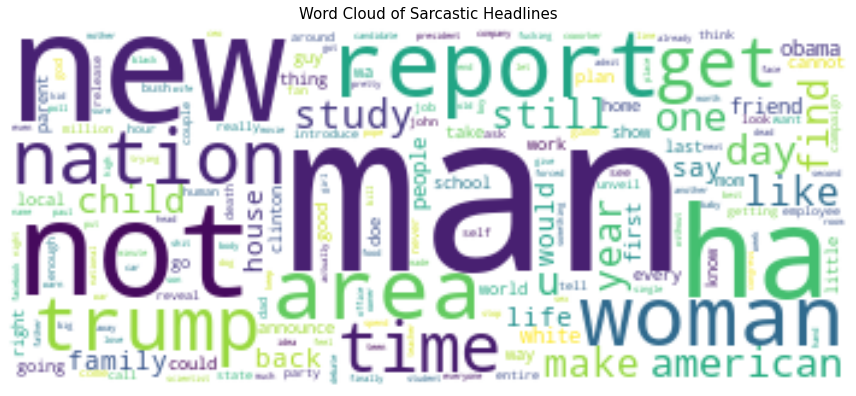

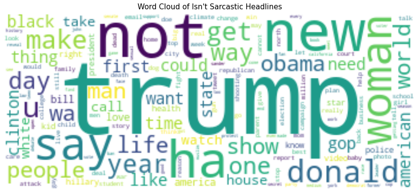

```python
data['headline'] = data['headline'].fillna('')
sarcastic_headlines = ' '.join(data.loc[data['is_sarcastic'] == 1, 'cleaned_headline'])
plot_wordcloud(sarcastic_headlines, title = 'Word Cloud of Sarcastic Headlines')

non_sarcastic_headlines = ' '.join(data.loc[data['is_sarcastic'] == 0, 'cleaned_headline'])
plot_wordcloud(non_sarcastic_headlines, title = 'Word Cloud of Isn\'t Sarcastic Headlines')
```

## Modelling

```python
## Setting Parameters

max_features = 10000
maxlen = data['nb_words'].max()
embedding_size = 50
```

```python
## Applying Keras Tokenizer

tokenizer = Tokenizer(num_words = max_features)
tokenizer.fit_on_texts(list(data['cleaned_headline']))
```

```python
## Seperate Features and Target Column (X and y)

X = tokenizer.texts_to_sequences(data['cleaned_headline'])
X = pad_sequences(X, maxlen = maxlen)
y = np.asarray(data['is_sarcastic'])

print(f'Number of Samples: {len(X)}')
print(f'Number of Labels: {len(y)}')
print(f'\nFirst headline:\n{X[0]}\n\nLabel of the first headline: {y[0]}')
```

```
Number of Samples: 28619
Number of Labels: 28619

First headline:
[   0    0    0    0    0    0    0    0    0    0    0    0    0    0
    0    0    0    0    0    0    0    0    0    0    0    0    0    0
    0    0    0    0    0    0    0    0    0    0    0    0    0    0
    0    0    0    0    0    0    0    0    0    0    0    0    0    0
    0    0    0    0    0    0    0    0    0    0    0    0    0    0
    0    0    0    0    0    0    0    0    0    0    0    0    0    0
    0    0    0    0    0    0    0    0    0    0    0    0    0    0
    0    0    0    0    0    0    0    0    0    0    0    0    0    0
    0    0    0    0    0    0    0    0    0    0    0    0    0    0
    0    0    0    0    0    0    0    0    0    0    0    0    0    0
    0    0    0    0  327 2957 5781 2067    2  692 1093]

Label of the first headline: 1
```

```python
## Size of the vocabulary:

# Reserve padding (indexed zero)
w2i = tokenizer.word_index
vocab_size = len(w2i) + 1
print(f'Number of unique tokens: {vocab_size}')
```

```
Number of unique tokens: 26042
```

## Load Word Embedding from Given file

```python
EMBEDDING_FILE = 'DataSet - glove.6B.50d.txt'

embeddings = {}
for o in open(EMBEDDING_FILE, encoding="utf8"):
    word = o.split(' ')[0]
    embd = o.split(' ')[1:]
    embd = np.asarray(embd, dtype = 'float32')
    embeddings[word] = embd
```

```python
# Getting the minimum number of words
num_words = min(max_features, vocab_size) + 1

embedding_matrix = np.zeros((num_words, embedding_size))
for word, i in tokenizer.word_index.items():
    if i > max_features: continue
    embedding_vector = embeddings.get(word)
    if embedding_vector is not None:
        embedding_matrix[i] = embedding_vector

len(embeddings.values())
```

```
400000
```

```python
x_train, x_test, y_train, y_test = train_test_split(X, y, test_size = 0.2, random_state = random_state, shuffle = True)

print(f'\nShape of training dataset: {x_train.shape}')
print(f'Unique words in training dataset: {len(np.unique(np.hstack(x_train)))}')

print('==='*15)
print(f'\nShape of test dataset: {x_test.shape}')
print(f'Number of unique words in test dataset: {len(np.unique(np.hstack(x_test)))}')
```

```
Shape of training dataset: (22895, 151)
Unique words in training dataset: 9975
=============================================

Shape of test dataset: (5724, 151)
Number of unique words in test dataset: 7640
```

## Create and Compile Model

```python
lstm_out = 196

# define the model
model = Sequential()
model.add(Embedding(num_words,
                    embedding_size,
                    embeddings_initializer=Constant(embedding_matrix),
                    input_length=maxlen,
                    trainable=False))
model.add(SpatialDropout1D(0.4))
model.add(Bidirectional(LSTM(lstm_out, dropout=0.2, recurrent_dropout=0.2)))
model.add(Flatten())
model.add(Dense(1, activation='sigmoid'))
model.compile(optimizer='adam', loss='binary_crossentropy', metrics=['accuracy'])
```

```python
# Adding callbacks
es = EarlyStopping(monitor = 'val_loss', mode = 'min', verbose = 1, patience = 10)
mc = ModelCheckpoint('sarcasm_detector.h5', monitor = 'val_loss', mode = 'min', save_best_only = True, verbose = 1)
lr_r = ReduceLROnPlateau(monitor = 'val_loss', factor = 0.1, patience = 5),
logdir = 'log'; tb = TensorBoard(logdir, histogram_freq = 1)
callbacks = [es, mc, lr_r, tb]
```

```python
batch_size = 64
epochs = 5

h = model.fit(x_train, y_train, epochs = epochs, validation_split = 0.2, batch_size = batch_size, verbose = 2, callbacks = callbacks)
```

```
287/287 - 858s - loss: 0.6469 - accuracy: 0.6209 - val_loss: 0.5819 - val_accuracy: 0.7060

Epoch 00001: val_loss improved from inf to 0.58186, saving model to sarcasm_detector.h5
287/287 - 1161s - loss: 0.6017 - accuracy: 0.6751 - val_loss: 0.5284 - val_accuracy: 0.7478

Epoch 00002: val_loss improved from 0.58186 to 0.52842, saving model to sarcasm_detector.h5
287/287 - 823s - loss: 0.5673 - accuracy: 0.7081 - val_loss: 0.4898 - val_accuracy: 0.7676

Epoch 00003: val_loss improved from 0.52842 to 0.48983, saving model to sarcasm_detector.h5
287/287 - 818s - loss: 0.5358 - accuracy: 0.7311 - val_loss: 0.4785 - val_accuracy: 0.7703

Epoch 00004: val_loss improved from 0.48983 to 0.47848, saving model to sarcasm_detector.h5
287/287 - 829s - loss: 0.5085 - accuracy: 0.7496 - val_loss: 0.4372 - val_accuracy: 0.7952

Epoch 00005: val_loss improved from 0.47848 to 0.43716, saving model to sarcasm_detector.h5
```

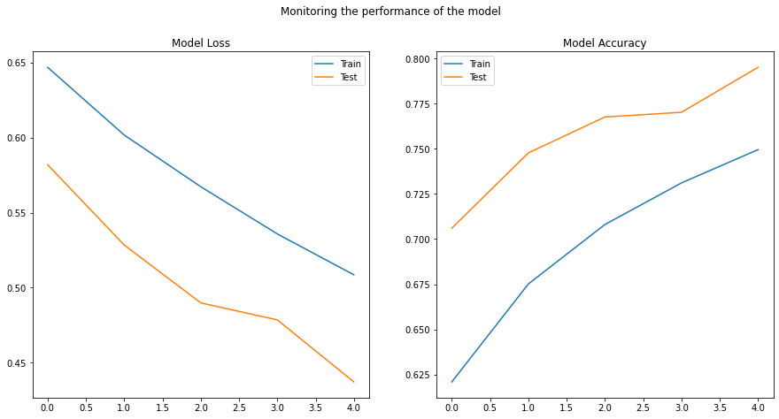

```python
f, (ax1, ax2) = plt.subplots(1, 2, figsize = (15, 7.2))
f.suptitle('Monitoring the performance of the model')

ax1.plot(h.history['loss'], label = 'Train')
ax1.plot(h.history['val_loss'], label = 'Test')
ax1.set_title('Model Loss')
ax1.legend(['Train', 'Test'])

ax2.plot(h.history['accuracy'], label = 'Train')
ax2.plot(h.history['val_accuracy'], label = 'Test')
ax2.set_title('Model Accuracy')
ax2.legend(['Train', 'Test'])

plt.show()
```

```python
# Evaluate the model
loss, accuracy = model.evaluate(x_test, y_test, verbose = 0)
print('Overall Accuracy: {}'.format(round(accuracy * 100, 0)))
```

```
Overall Accuracy: 80.0
```

## Classification Report and Confusion Matrix

```python
## Classification Report

from sklearn import metrics

y_pred = (model.predict(x_test) > 0.5).astype('int32')

print('Classification report: ')
display_label = ["Sarcastic", "Non-Sarcastic"]
print(classification_report(y_test,y_pred, target_names=display_label))
```

[output not shown]

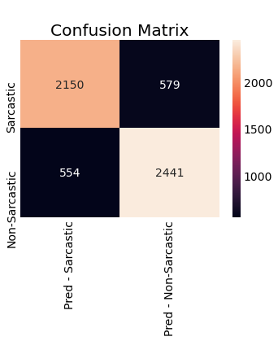

```python
## Confusion Matix

lab = [1,0]
cm = metrics.confusion_matrix(y_test, y_pred, labels=lab)
plab=[f"Pred - {s}" for s in display_label]
df_cm = pd.DataFrame(cm, index = display_label, columns = plab)
plt.figure(figsize = (5.5,4))
style.use('fivethirtyeight')
sns.heatmap(df_cm, annot=True, fmt='g')
plt.title(f'\nConfusion Matrix')
plt.show()
```

## Conclusion

At first we had done data preprocessing to clean the data and then fit the data to the model, the model is created using bidirectional LSTM.

The Overall Accuracy we achieved: 80%

The Overall Accuracy can be further improved if we train the model for more epochs, But I kept it low for want of compute power.